# Python Foundations Project: FoodHub Data Analysis

## Conclusion and Recommendations

### **Question 17:** What are your conclusions from the analysis? What recommendations would you like to share to help improve the business? (You can use cuisine type and feedback ratings to drive your business recommendations.)

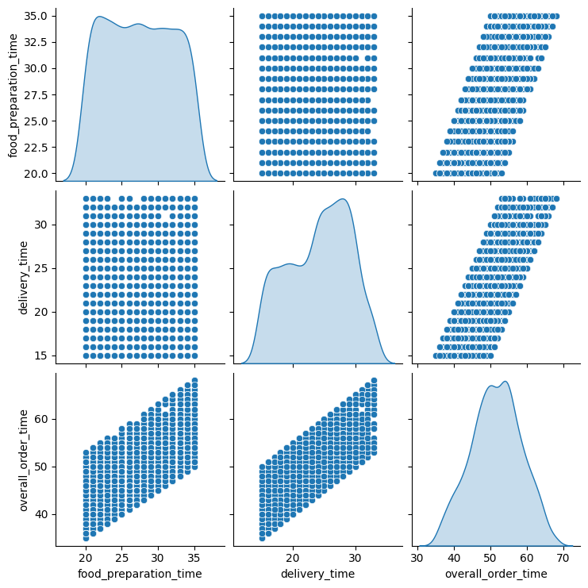

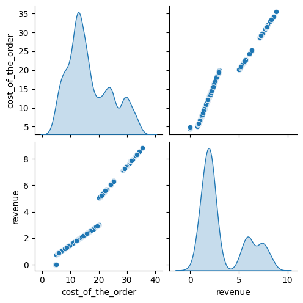

```python
# Display the relationship of numerical columns with correlations (food_preparation_time, delivery_time, overall_order_time, cost_of_the_order, revenue)
data = df[['food_preparation_time', 'delivery_time', 'overall_order_time']]

ax = sns.pairplot(data = data, diag_kind = 'kde')

plt.show()

data = df[['cost_of_the_order', 'revenue']]

ax = sns.pairplot(data = data, diag_kind = 'kde')

plt.show()
```

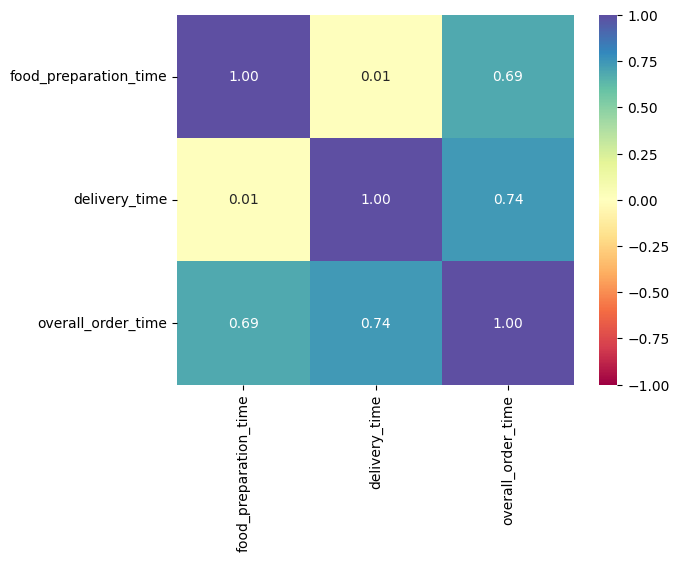

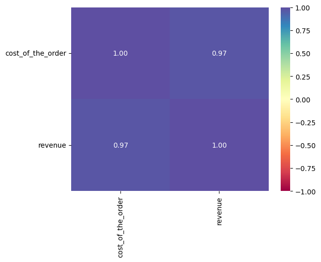

```python
# Display the relationship of numerical columns with correlations (food_preparation_time, delivery_time, overall_order_time, cost_of_the_order, revenue)
data = df[['food_preparation_time', 'delivery_time', 'overall_order_time']].corr()

ax = sns.heatmap(data = data, annot = True, vmin = -1, vmax = 1, fmt = '.2f', cmap = 'Spectral')

plt.xticks(rotation = 90)
plt.yticks(rotation = 0)
plt.show()

data = df[['cost_of_the_order', 'revenue']].corr()

ax = sns.heatmap(data = data, annot = True, vmin = -1, vmax = 1, fmt = '.2f', cmap = 'Spectral')

plt.xticks(rotation = 90)
plt.yticks(rotation = 0)
plt.show()
```

```python
# Display the revenue for orders greater than 5 dollars and less than or equal to 20 dollars
df[(df['cost_of_the_order'] > 5) & (df['cost_of_the_order'] <= 20)]['revenue'].sum()
```

```
2477.5755
```

```python
# Display the revenue for orders greater than 20 dollars
df[df['cost_of_the_order'] > 20]['revenue'].sum()
```

```
3688.7275
```

### Conclusions:

- About 50% of the customers that rated their orders gave a 5 rating which indicates that customers are happy. However, about 38% of the total orders are not rated, which may greatly impact the result of the ratings.
- About 59.82% (or 3,688.73 dollars) of the revenue of FoodHub comes from orders greater than 20 dollars. This indicates the higher the cost of order by the customer, the bigger the revenue for the FoodHub business.
- Total Order Time is relatively consistent with Food Preparation Time and Delivery Time. This means both Preparation Time and Delivery Time are significant factors for the delivery of the food to the customer.
- There is a consistent popularity of the cuisines regardless if it is weekday or weekend.

### Recommendations:

- Increase the customer rating response to allow a more accurate assessment of orders/ restaurants. If possible, request a follow-up to the customer for orders that are not rated.
- The majority of the revenue of FoodHub comes from orders greater than 20 dollars. If possible, offer promotions to customers to make orders above 20 dollars.
- To reduce the Total Order Time to deliver the food to the customer, a review on how to reduce the Delivery Time will be important since it can reduce the Total Order Time.
- Since there is a consistent popularity of the cuisines regardless if it is weekday or weekend, better marketing can be focused on weekdays to boost the number of orders.